# Final project ML

Carlo Javier Chazarreta

2024-02-25

Click through the tabs to explore our results

### Setup

```r
library(tidyverse)
library(caret)
library(skimr)
```

### Data

```r
training <- read_csv("https://d396qusza40orc.cloudfront.net/predmachlearn/pml-training.csv",
                    na = c("NA", "#DIV/0!", ""))
testing <- read_csv("https://d396qusza40orc.cloudfront.net/predmachlearn/pml-testing.csv",
                    na = c("NA", "#DIV/0!", ""))

training %>%
  skimr::skim()
```

Data summary

| Name | Piped data |
| --- | --- |
| Number of rows | 19622 |
| Number of columns | 160 |
| _______________________ |  |
| Column type frequency: |  |
| character | 4 |
| logical | 6 |
| numeric | 150 |
| ________________________ |  |
| Group variables | None |

**Variable type: character**

| skim_variable | n_missing | complete_rate | min | max | empty | n_unique | whitespace |
| --- | --- | --- | --- | --- | --- | --- | --- |
| user_name | 0 | 1 | 5 | 8 | 0 | 6 | 0 |
| cvtd_timestamp | 0 | 1 | 16 | 16 | 0 | 20 | 0 |
| new_window | 0 | 1 | 2 | 3 | 0 | 2 | 0 |
| classe | 0 | 1 | 1 | 1 | 0 | 5 | 0 |

**Variable type: logical**

| skim_variable | n_missing | complete_rate | mean | count |
| --- | --- | --- | --- | --- |
| kurtosis_yaw_belt | 19622 | 0 | NaN | : |
| skewness_yaw_belt | 19622 | 0 | NaN | : |
| kurtosis_yaw_dumbbell | 19622 | 0 | NaN | : |
| skewness_yaw_dumbbell | 19622 | 0 | NaN | : |
| kurtosis_yaw_forearm | 19622 | 0 | NaN | : |
| skewness_yaw_forearm | 19622 | 0 | NaN | : |

**Variable type: numeric**

| skim_variable | n_missing | complete_rate | mean | sd | p0 | p25 | p50 | p75 | p100 | hist |
| --- | --- | --- | --- | --- | --- | --- | --- | --- | --- | --- |
| …1 | 0 | 1.00 | 9811.50 | 5664.53 | 1.00000e+00 | 4906.25 | 9811.50 | 14716.75 | 1.962200e+04 | ▇▇▇▇▇ |
| raw_timestamp_part_1 | 0 | 1.00 | 1322827119.27 | 204927.68 | 1.32249e+09 | 1322673099.00 | 1322832920.00 | 1323084264.00 | 1.323095e+09 | ▃▃▇▁▆ |
| raw_timestamp_part_2 | 0 | 1.00 | 500656.14 | 288222.88 | 2.94000e+02 | 252912.25 | 496380.00 | 751890.75 | 9.988010e+05 | ▇▇▇▇▇ |
| num_window | 0 | 1.00 | 430.64 | 247.91 | 1.00000e+00 | 222.00 | 424.00 | 644.00 | 8.640000e+02 | ▇▇▇▇▇ |
| roll_belt | 0 | 1.00 | 64.41 | 62.75 | -2.89000e+01 | 1.10 | 113.00 | 123.00 | 1.620000e+02 | ▇▁▁▅▅ |
| pitch_belt | 0 | 1.00 | 0.31 | 22.35 | -5.58000e+01 | 1.76 | 5.28 | 14.90 | 6.030000e+01 | ▃▁▇▅▁ |
| yaw_belt | 0 | 1.00 | -11.21 | 95.19 | -1.80000e+02 | -88.30 | -13.00 | 12.90 | 1.790000e+02 | ▁▇▅▁▃ |
| total_accel_belt | 0 | 1.00 | 11.31 | 7.74 | 0.00000e+00 | 3.00 | 17.00 | 18.00 | 2.900000e+01 | ▇▁▂▆▁ |
| kurtosis_roll_belt | 19226 | 0.02 | -0.22 | 2.92 | -2.12000e+00 | -1.33 | -0.90 | -0.22 | 3.300000e+01 | ▇▁▁▁▁ |
| kurtosis_picth_belt | 19248 | 0.02 | 4.33 | 11.58 | -2.19000e+00 | -1.11 | -0.15 | 3.18 | 5.800000e+01 | ▇▁▁▁▁ |
| skewness_roll_belt | 19225 | 0.02 | -0.03 | 0.92 | -5.74000e+00 | -0.44 | 0.00 | 0.42 | 3.600000e+00 | ▁▁▆▇▁ |
| skewness_roll_belt.1 | 19248 | 0.02 | -0.30 | 2.26 | -7.62000e+00 | -1.11 | -0.07 | 0.66 | 7.350000e+00 | ▁▂▇▁▁ |
| max_roll_belt | 19216 | 0.02 | -6.67 | 94.59 | -9.43000e+01 | -88.00 | -5.10 | 18.50 | 1.800000e+02 | ▇▅▁▁▃ |
| max_picth_belt | 19216 | 0.02 | 12.92 | 8.01 | 3.00000e+00 | 5.00 | 18.00 | 19.00 | 3.000000e+01 | ▇▁▆▃▁ |
| max_yaw_belt | 19226 | 0.02 | -0.22 | 2.92 | -2.10000e+00 | -1.30 | -0.90 | -0.20 | 3.300000e+01 | ▇▁▁▁▁ |
| min_roll_belt | 19216 | 0.02 | -10.44 | 93.62 | -1.80000e+02 | -88.40 | -7.85 | 9.05 | 1.730000e+02 | ▁▇▅▁▃ |
| min_pitch_belt | 19216 | 0.02 | 10.76 | 7.47 | 0.00000e+00 | 3.00 | 16.00 | 17.00 | 2.300000e+01 | ▇▁▁▇▂ |
| min_yaw_belt | 19226 | 0.02 | -0.22 | 2.92 | -2.10000e+00 | -1.30 | -0.90 | -0.20 | 3.300000e+01 | ▇▁▁▁▁ |
| amplitude_roll_belt | 19216 | 0.02 | 3.77 | 25.26 | 0.00000e+00 | 0.30 | 1.00 | 2.08 | 3.600000e+02 | ▇▁▁▁▁ |
| amplitude_pitch_belt | 19216 | 0.02 | 2.17 | 2.36 | 0.00000e+00 | 1.00 | 1.00 | 2.00 | 1.200000e+01 | ▇▁▁▁▁ |
| amplitude_yaw_belt | 19226 | 0.02 | 0.00 | 0.00 | 0.00000e+00 | 0.00 | 0.00 | 0.00 | 0.000000e+00 | ▁▁▇▁▁ |
| var_total_accel_belt | 19216 | 0.02 | 0.93 | 2.22 | 0.00000e+00 | 0.10 | 0.20 | 0.30 | 1.650000e+01 | ▇▁▁▁▁ |
| avg_roll_belt | 19216 | 0.02 | 68.06 | 63.14 | -2.74000e+01 | 1.10 | 116.35 | 123.38 | 1.574000e+02 | ▇▁▁▃▆ |
| stddev_roll_belt | 19216 | 0.02 | 1.34 | 2.44 | 0.00000e+00 | 0.20 | 0.40 | 0.70 | 1.420000e+01 | ▇▁▁▁▁ |
| var_roll_belt | 19216 | 0.02 | 7.70 | 23.16 | 0.00000e+00 | 0.00 | 0.10 | 0.50 | 2.007000e+02 | ▇▁▁▁▁ |
| avg_pitch_belt | 19216 | 0.02 | 0.52 | 22.41 | -5.14000e+01 | 2.02 | 5.20 | 15.78 | 5.970000e+01 | ▃▁▇▃▁ |
| stddev_pitch_belt | 19216 | 0.02 | 0.60 | 0.64 | 0.00000e+00 | 0.20 | 0.40 | 0.70 | 4.000000e+00 | ▇▁▁▁▁ |
| var_pitch_belt | 19216 | 0.02 | 0.77 | 1.76 | 0.00000e+00 | 0.00 | 0.10 | 0.50 | 1.620000e+01 | ▇▁▁▁▁ |
| avg_yaw_belt | 19216 | 0.02 | -8.83 | 93.48 | -1.38300e+02 | -88.18 | -6.55 | 14.12 | 1.735000e+02 | ▇▁▅▁▃ |
| stddev_yaw_belt | 19216 | 0.02 | 1.34 | 10.29 | 0.00000e+00 | 0.10 | 0.30 | 0.70 | 1.766000e+02 | ▇▁▁▁▁ |

[output cut: 120 more lines]

### Exploratory Data Analisys

From the data tab we can see that all the logical variables only have NAs and must be deleted to improve the model. Also, we can see that some features has a very low complete rate, so they have a lot of NAs. I check that with a plot

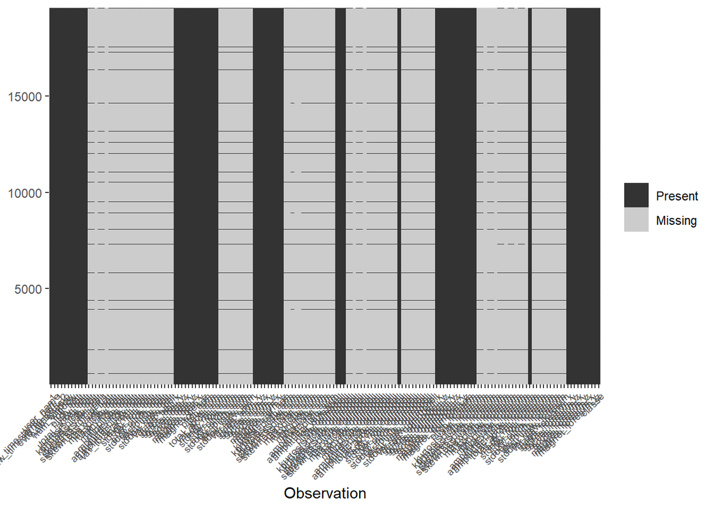

```r
# visualizing NAs
training %>%
  is.na() %>%
  reshape2::melt() %>%
  ggplot(aes(Var2, Var1, fill = value)) +
  geom_raster() +
  scale_y_continuous(NULL, expand = c(0, 0)) +
  scale_fill_grey(name = "",
                  labels = c("Present",
                             "Missing")) +
  xlab("Observation") +
  theme(axis.text.x  = element_text(size = 7, angle = 45,
                                    hjust = 1, vjust = 1))
```

```r
training %>%
  # select only character, factor or variables
  select(where(is.character) | where(is.factor)) %>%

  # calculate the proportion of unique categories in every variable
  apply(., FUN = \(x) table(x) / length(x), MARGIN = 2)
```

```
## $user_name
## x
##    adelmo  carlitos   charles    eurico    jeremy     pedro
## 0.1983488 0.1585975 0.1802059 0.1564570 0.1733768 0.1330140
##
## $cvtd_timestamp
## x
## 02/12/2011 13:32 02/12/2011 13:33 02/12/2011 13:34 02/12/2011 13:35
##      0.009020487      0.067322393      0.070074406      0.051931505
## 02/12/2011 14:56 02/12/2011 14:57 02/12/2011 14:58 02/12/2011 14:59
##      0.011976353      0.070329222      0.069513811      0.028386505
## 05/12/2011 11:23 05/12/2011 11:24 05/12/2011 11:25 05/12/2011 14:22
##      0.009683009      0.076291917      0.072622567      0.013607176
## 05/12/2011 14:23 05/12/2011 14:24 28/11/2011 14:13 28/11/2011 14:14
##      0.069819590      0.049587198      0.042452349      0.076342880
## 28/11/2011 14:15 30/11/2011 17:10 30/11/2011 17:11 30/11/2011 17:12
##      0.037661808      0.044287025      0.073387015      0.055702783
##
## $new_window
## x
##         no        yes
## 0.97930894 0.02069106
##
## $classe
## x
##         A         B         C         D         E
## 0.2843747 0.1935073 0.1743961 0.1638977 0.1838243
```

### Preprocessing

Based on the fact that the data has a lot of NAs the imputation methods are not useful and the features with more than 90% of NAs should be deleted to improve the modelling. So in the first step of the presprossecing process I filtered the data to get just the features that doesn’t have NAs. In the second step I deleted the new_windows and …1 variables. I applied I did it to both the training and testing dataset. To improve the speed of the modelling process I trained the model on a sample of 1000 rows selected at random from the training dataset.

```r
features <- training[sample(nrow(training), 1000), ] %>%
  skimr::skim() %>%
  select(skim_variable, complete_rate) %>%
  # filter complete features
  filter(complete_rate == 1) %>%
  pull(skim_variable)

train_df <- training[sample(nrow(training), 1000), ] %>%
  select(all_of(features)) %>%
  # delete new_windows and ...1 because they are near zero variance and a rowname
  # variable respectively
  select(-c(new_window, ...1))

test_df <- testing %>%
  select(all_of(features[!features == 'classe'])) %>%
  select(-c(new_window, ...1))
```

### Model

Finally I applied a random forest model because it is versatile, robust, and suitable for various classification tasks and offers some advantages such as high accuracy, robustness to outliers, and no assumption about data distribution. I selected the resampling method ‘cv’ in the trainControl function to apply cross-validation. The Mtry parameter controls how many features are available to be considered for each new split in every tree.

#### Train the model

```r
fit_rf <- train(classe ~ ., data = train_df, method = 'rf', prox = TRUE,
                trControl = trainControl(method = 'cv'))
```

```r
fit_rf
```

```
## Random Forest
##
## 1000 samples
##   57 predictor
##    5 classes: 'A', 'B', 'C', 'D', 'E'
##
## No pre-processing
## Resampling: Cross-Validated (10 fold)
## Summary of sample sizes: 900, 900, 901, 900, 900, 898, ...
## Resampling results across tuning parameters:
##
##   mtry  Accuracy   Kappa
##    2    0.9540852  0.9420556
##   40    0.9770867  0.9711073
##   79    0.9741365  0.9673938
##
## Accuracy was used to select the optimal model using the largest value.
## The final value used for the model was mtry = 40.
```

#### Predicting

The result of predicting the 20 provided test cases were the following:

```r
predict(fit_rf, test_df)
```

```
##  [1] B A B A A E D B A A B C B A E E A B B B
## Levels: A B C D E
```